# PDL-churn

```python
import pandas as pd # manipulation des DataFrame (tableau de données)
import numpy as np # calcul scientifique
import matplotlib.pyplot as plt # visualisation (module pyplot : 2D)
import seaborn as sns # manipulation et visualisation des stats
```

### Aperçu des données

```python
churn_c = pd.read_csv('D:/sesame etude/4eme semestre 2 2022-2023/PDL churn/dataset/Telco_customer_churn.csv')
churn_c
```

|  | CustomerID | Count | Country | State | City | Zip Code | Lat Long | Latitude | Longitude | Gender | ... | Contract | Paperless Billing | Payment Method | Monthly Charges | Total Charges | Churn Label | Churn Value | Churn Score | CLTV | Churn Reason |
| --- | --- | --- | --- | --- | --- | --- | --- | --- | --- | --- | --- | --- | --- | --- | --- | --- | --- | --- | --- | --- | --- |
| 0 | 3668-QPYBK | 1 | United States | California | Los Angeles | 90003 | 33.964131, -118.272783 | 33.964131 | -118.272783 | Male | ... | Month-to-month | Yes | Mailed check | 53.85 | 108.15 | Yes | 1 | 86 | 3239 | Competitor made better offer |
| 1 | 9237-HQITU | 1 | United States | California | Los Angeles | 90005 | 34.059281, -118.30742 | 34.059281 | -118.307420 | Female | ... | Month-to-month | Yes | Electronic check | 70.70 | 151.65 | Yes | 1 | 67 | 2701 | Moved |
| 2 | 9305-CDSKC | 1 | United States | California | Los Angeles | 90006 | 34.048013, -118.293953 | 34.048013 | -118.293953 | Female | ... | Month-to-month | Yes | Electronic check | 99.65 | 820.5 | Yes | 1 | 86 | 5372 | Moved |
| 3 | 7892-POOKP | 1 | United States | California | Los Angeles | 90010 | 34.062125, -118.315709 | 34.062125 | -118.315709 | Female | ... | Month-to-month | Yes | Electronic check | 104.80 | 3046.05 | Yes | 1 | 84 | 5003 | Moved |
| 4 | 0280-XJGEX | 1 | United States | California | Los Angeles | 90015 | 34.039224, -118.266293 | 34.039224 | -118.266293 | Male | ... | Month-to-month | Yes | Bank transfer (automatic) | 103.70 | 5036.3 | Yes | 1 | 89 | 5340 | Competitor had better devices |
| ... | ... | ... | ... | ... | ... | ... | ... | ... | ... | ... | ... | ... | ... | ... | ... | ... | ... | ... | ... | ... | ... |
| 7038 | 2569-WGERO | 1 | United States | California | Landers | 92285 | 34.341737, -116.539416 | 34.341737 | -116.539416 | Female | ... | Two year | Yes | Bank transfer (automatic) | 21.15 | 1419.4 | No | 0 | 45 | 5306 | NaN |
| 7039 | 6840-RESVB | 1 | United States | California | Adelanto | 92301 | 34.667815, -117.536183 | 34.667815 | -117.536183 | Male | ... | One year | Yes | Mailed check | 84.80 | 1990.5 | No | 0 | 59 | 2140 | NaN |
| 7040 | 2234-XADUH | 1 | United States | California | Amboy | 92304 | 34.559882, -115.637164 | 34.559882 | -115.637164 | Female | ... | One year | Yes | Credit card (automatic) | 103.20 | 7362.9 | No | 0 | 71 | 5560 | NaN |
| 7041 | 4801-JZAZL | 1 | United States | California | Angelus Oaks | 92305 | 34.1678, -116.86433 | 34.167800 | -116.864330 | Female | ... | Month-to-month | Yes | Electronic check | 29.60 | 346.45 | No | 0 | 59 | 2793 | NaN |
| 7042 | 3186-AJIEK | 1 | United States | California | Apple Valley | 92308 | 34.424926, -117.184503 | 34.424926 | -117.184503 | Male | ... | Two year | Yes | Bank transfer (automatic) | 105.65 | 6844.5 | No | 0 | 38 | 5097 | NaN |

7043 rows × 33 columns

```python
churn_c.shape
```

```
(7043, 33)
```

```python
print('le nombre de lignes est {}'.format(churn_c.shape[0]))
print('le nombre de colonnes est {}'.format(churn_c.shape[1]))
```

```
le nombre de lignes est 7043
le nombre de colonnes est 33
```

```python
churn_c.info()
```

```
<class 'pandas.core.frame.DataFrame'>
RangeIndex: 7043 entries, 0 to 7042
Data columns (total 33 columns):
 #   Column             Non-Null Count  Dtype
---  ------             --------------  -----
 0   CustomerID         7043 non-null   object
 1   Count              7043 non-null   int64
 2   Country            7043 non-null   object
 3   State              7043 non-null   object
 4   City               7043 non-null   object
 5   Zip Code           7043 non-null   int64
 6   Lat Long           7043 non-null   object
 7   Latitude           7043 non-null   float64
 8   Longitude          7043 non-null   float64
 9   Gender             7043 non-null   object
```

[output cut: 25 more lines]

```python
churn_c.head()
```

|  | CustomerID | Count | Country | State | City | Zip Code | Lat Long | Latitude | Longitude | Gender | ... | Contract | Paperless Billing | Payment Method | Monthly Charges | Total Charges | Churn Label | Churn Value | Churn Score | CLTV | Churn Reason |
| --- | --- | --- | --- | --- | --- | --- | --- | --- | --- | --- | --- | --- | --- | --- | --- | --- | --- | --- | --- | --- | --- |
| 0 | 3668-QPYBK | 1 | United States | California | Los Angeles | 90003 | 33.964131, -118.272783 | 33.964131 | -118.272783 | Male | ... | Month-to-month | Yes | Mailed check | 53.85 | 108.15 | Yes | 1 | 86 | 3239 | Competitor made better offer |
| 1 | 9237-HQITU | 1 | United States | California | Los Angeles | 90005 | 34.059281, -118.30742 | 34.059281 | -118.307420 | Female | ... | Month-to-month | Yes | Electronic check | 70.70 | 151.65 | Yes | 1 | 67 | 2701 | Moved |
| 2 | 9305-CDSKC | 1 | United States | California | Los Angeles | 90006 | 34.048013, -118.293953 | 34.048013 | -118.293953 | Female | ... | Month-to-month | Yes | Electronic check | 99.65 | 820.5 | Yes | 1 | 86 | 5372 | Moved |
| 3 | 7892-POOKP | 1 | United States | California | Los Angeles | 90010 | 34.062125, -118.315709 | 34.062125 | -118.315709 | Female | ... | Month-to-month | Yes | Electronic check | 104.80 | 3046.05 | Yes | 1 | 84 | 5003 | Moved |
| 4 | 0280-XJGEX | 1 | United States | California | Los Angeles | 90015 | 34.039224, -118.266293 | 34.039224 | -118.266293 | Male | ... | Month-to-month | Yes | Bank transfer (automatic) | 103.70 | 5036.3 | Yes | 1 | 89 | 5340 | Competitor had better devices |

5 rows × 33 columns

```python
churn_c.tail()
```

|  | CustomerID | Count | Country | State | City | Zip Code | Lat Long | Latitude | Longitude | Gender | ... | Contract | Paperless Billing | Payment Method | Monthly Charges | Total Charges | Churn Label | Churn Value | Churn Score | CLTV | Churn Reason |
| --- | --- | --- | --- | --- | --- | --- | --- | --- | --- | --- | --- | --- | --- | --- | --- | --- | --- | --- | --- | --- | --- |
| 7038 | 2569-WGERO | 1 | United States | California | Landers | 92285 | 34.341737, -116.539416 | 34.341737 | -116.539416 | Female | ... | Two year | Yes | Bank transfer (automatic) | 21.15 | 1419.4 | No | 0 | 45 | 5306 | NaN |
| 7039 | 6840-RESVB | 1 | United States | California | Adelanto | 92301 | 34.667815, -117.536183 | 34.667815 | -117.536183 | Male | ... | One year | Yes | Mailed check | 84.80 | 1990.5 | No | 0 | 59 | 2140 | NaN |
| 7040 | 2234-XADUH | 1 | United States | California | Amboy | 92304 | 34.559882, -115.637164 | 34.559882 | -115.637164 | Female | ... | One year | Yes | Credit card (automatic) | 103.20 | 7362.9 | No | 0 | 71 | 5560 | NaN |
| 7041 | 4801-JZAZL | 1 | United States | California | Angelus Oaks | 92305 | 34.1678, -116.86433 | 34.167800 | -116.864330 | Female | ... | Month-to-month | Yes | Electronic check | 29.60 | 346.45 | No | 0 | 59 | 2793 | NaN |
| 7042 | 3186-AJIEK | 1 | United States | California | Apple Valley | 92308 | 34.424926, -117.184503 | 34.424926 | -117.184503 | Male | ... | Two year | Yes | Bank transfer (automatic) | 105.65 | 6844.5 | No | 0 | 38 | 5097 | NaN |

5 rows × 33 columns

```python
#supprimer la colonne CustomerID
churn_c = churn_c.drop('CustomerID', axis=1)
```

```python
#Renommer la colonne target Churn Label par Churn
churn_c = churn_c.rename(columns={'Churn Label': 'Churn'})
```

```python
#Calculer le nombre de valeurs distinctes dans Churn
n_distinct_values = churn_c['Churn'].nunique()

# Afficher le nombre de récurrence de chaque valeur dans Churn
value_counts = churn_c['Churn'].value_counts()

print("Nombre de valeurs distinctes dans Colonne1 : ", n_distinct_values)
print("Nombre de récurrence de chaque valeur dans Colonne1 : \n", value_counts)
```

```
Nombre de valeurs distinctes dans Colonne1 :  2
Nombre de récurrence de chaque valeur dans Colonne1 :
 No     5174
Yes    1869
Name: Churn, dtype: int64
```

```python
# Parcourir toutes les colonnes du dataframe
for col in churn_c.columns:

    # Calculer le nombre de valeurs distinctes dans la colonne
    n_distinct_values = churn_c[col].nunique()

    # Afficher le nombre de récurrences de chaque valeur dans la colonne
    value_counts = churn_c[col].value_counts()

    # Afficher les résultats
    print("Colonne : ", col)
    print("Nombre de valeurs distinctes : ", n_distinct_values)
    print("Nombre de récurrence de chaque valeur : \n", value_counts)
    print("\n")
```

```
Colonne :  Count
Nombre de valeurs distinctes :  1
Nombre de récurrence de chaque valeur :
 1    7043
Name: Count, dtype: int64


Colonne :  Country
Nombre de valeurs distinctes :  1
Nombre de récurrence de chaque valeur :
 United States    7043
Name: Country, dtype: int64


Colonne :  State
Nombre de valeurs distinctes :  1
Nombre de récurrence de chaque valeur :
 California    7043
Name: State, dtype: int64


Colonne :  City
Nombre de valeurs distinctes :  1129
Nombre de récurrence de chaque valeur :
 Los Angeles       305
San Diego         150
San Jose          112
Sacramento        108
San Francisco     104
                 ...
Healdsburg          4
Jenner              4
Philo               4
Point Arena         4
Olympic Valley      4
Name: City, Length: 1129, dtype: int64


Colonne :  Zip Code
Nombre de valeurs distinctes :  1652
```

[output cut: 315 more lines]

```
Competitor had better devices                130
Network reliability                          103
Product dissatisfaction                      102
Price too high                                98
Service dissatisfaction                       89
Lack of self-service on Website               88
Extra data charges                            57
Moved                                         53
Limited range of services                     44
Long distance charges                         44
Lack of affordable download/upload speed      44
Poor expertise of phone support               20
Poor expertise of online support              19
Deceased                                       6
Name: Churn Reason, dtype: int64
```

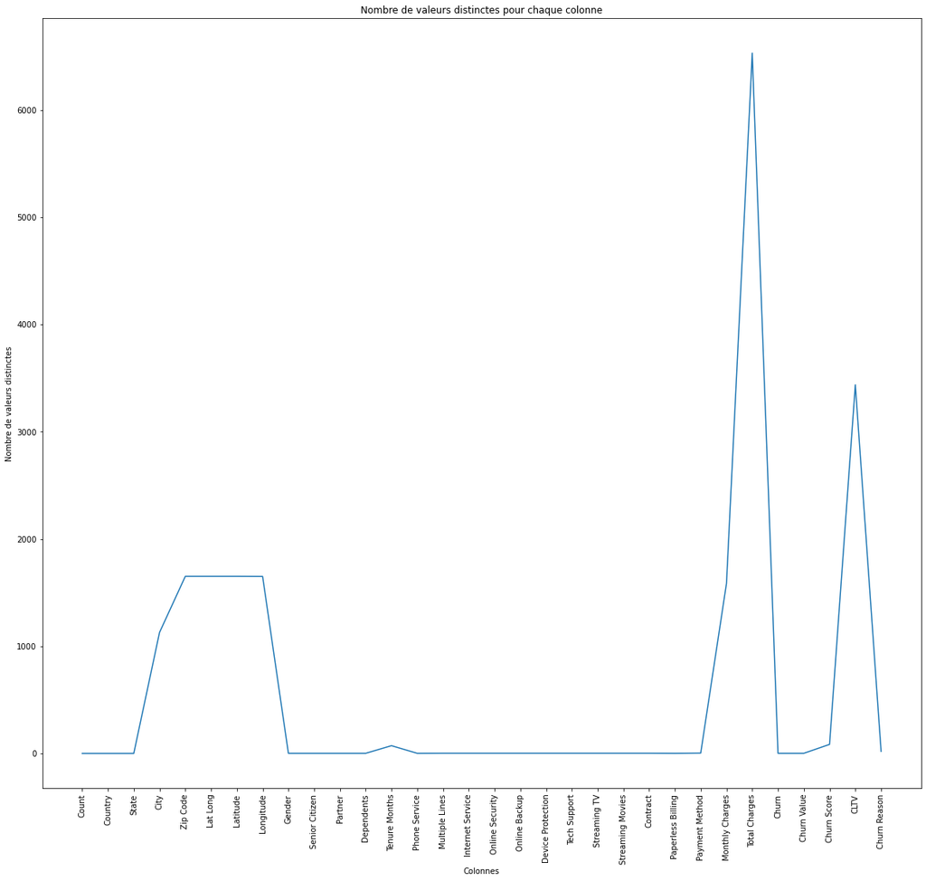

```python
# Créer une liste des colonnes à traiter
columns = ['Count', 'Country', 'State', 'City', 'Zip Code', 'Lat Long', 'Latitude', 'Longitude',
           'Gender', 'Senior Citizen', 'Partner', 'Dependents', 'Tenure Months', 'Phone Service',
           'Multiple Lines', 'Internet Service', 'Online Security', 'Online Backup', 'Device Protection',
           'Tech Support', 'Streaming TV', 'Streaming Movies', 'Contract', 'Paperless Billing',
           'Payment Method', 'Monthly Charges', 'Total Charges', 'Churn', 'Churn Value', 'Churn Score',
           'CLTV', 'Churn Reason']

# Créer une liste pour stocker le nombre de valeurs distinctes de chaque colonne
distinct_counts = []

# Calculer le nombre de valeurs distinctes pour chaque colonne et stocker le résultat dans la liste distinct_counts
for column in columns:
    distinct_counts.append(churn_c[column].nunique())

# Créer une figure de taille 20x18 pouces
plt.figure(figsize=(20,18))

# Créer un diagramme en courbe pour visualiser le nombre de valeurs distinctes pour chaque colonne
plt.plot(columns, distinct_counts)
plt.xticks(rotation=90)
plt.xlabel('Colonnes')
plt.ylabel('Nombre de valeurs distinctes')
plt.title('Nombre de valeurs distinctes pour chaque colonne')
plt.show()
```

### les colonnes Count, Country et State contiennent une seule valeur inutile dans notre analyse. Donc on va les supprimer

```python
#supprimer la colonne Count
churn_c = churn_c.drop('Count', axis=1)
```

```python
#supprimer la colonne Country
churn_c = churn_c.drop('Country', axis=1)
```

```python
#supprimer la colonne State
churn_c = churn_c.drop('State', axis=1)
```

###### Les colonnes Lat Long, Latitude et Longitude sont aussi inutile pour notre étude, dons on va les supprimer

```python
churn_c = churn_c.drop('Lat Long', axis=1)
churn_c = churn_c.drop('Latitude', axis=1)
churn_c = churn_c.drop('Longitude', axis=1)
```

```python
churn_c.head()
```

|  | City | Zip Code | Gender | Senior Citizen | Partner | Dependents | Tenure Months | Phone Service | Multiple Lines | Internet Service | ... | Contract | Paperless Billing | Payment Method | Monthly Charges | Total Charges | Churn | Churn Value | Churn Score | CLTV | Churn Reason |
| --- | --- | --- | --- | --- | --- | --- | --- | --- | --- | --- | --- | --- | --- | --- | --- | --- | --- | --- | --- | --- | --- |
| 0 | Los Angeles | 90003 | Male | No | No | No | 2 | Yes | No | DSL | ... | Month-to-month | Yes | Mailed check | 53.85 | 108.15 | Yes | 1 | 86 | 3239 | Competitor made better offer |
| 1 | Los Angeles | 90005 | Female | No | No | Yes | 2 | Yes | No | Fiber optic | ... | Month-to-month | Yes | Electronic check | 70.70 | 151.65 | Yes | 1 | 67 | 2701 | Moved |
| 2 | Los Angeles | 90006 | Female | No | No | Yes | 8 | Yes | Yes | Fiber optic | ... | Month-to-month | Yes | Electronic check | 99.65 | 820.5 | Yes | 1 | 86 | 5372 | Moved |
| 3 | Los Angeles | 90010 | Female | No | Yes | Yes | 28 | Yes | Yes | Fiber optic | ... | Month-to-month | Yes | Electronic check | 104.80 | 3046.05 | Yes | 1 | 84 | 5003 | Moved |
| 4 | Los Angeles | 90015 | Male | No | No | Yes | 49 | Yes | Yes | Fiber optic | ... | Month-to-month | Yes | Bank transfer (automatic) | 103.70 | 5036.3 | Yes | 1 | 89 | 5340 | Competitor had better devices |

5 rows × 26 columns

### Visualisation des NA dans les colonnes

```
City                    0
Zip Code                0
Gender                  0
Senior Citizen          0
Partner                 0
Dependents              0
Tenure Months           0
Phone Service           0
Multiple Lines          0
Internet Service        0
Online Security         0
Online Backup           0
Device Protection       0
Tech Support            0
Streaming TV            0
Streaming Movies        0
Contract                0
Paperless Billing       0
Payment Method          0
Monthly Charges         0
Total Charges           0
Churn                   0
Churn Value             0
Churn Score             0
CLTV                    0
Churn Reason         5174
dtype: int64
```

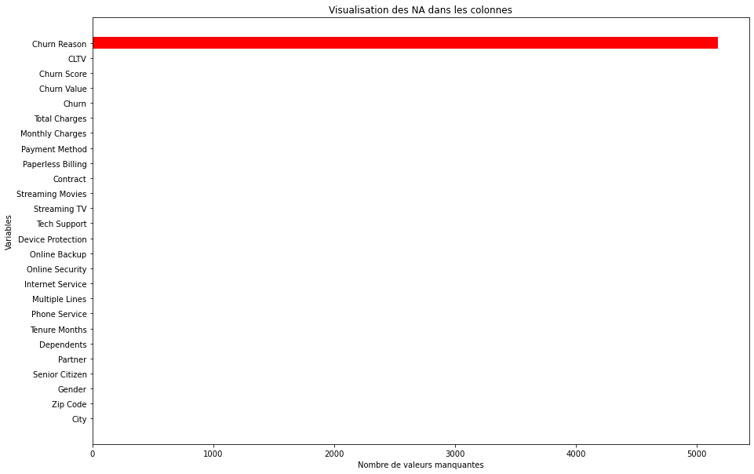

```python
# Créer une figure avec une taille de 15x10 pouces
plt.figure(figsize=(15, 10))

# Créer un DataFrame booléen indiquant les emplacements des valeurs manquantes
is_na = churn_c.isnull()

# Calculer le nombre total de valeurs manquantes dans chaque colonne
num_na = is_na.sum()

#afficher le nombre des NA
print(num_na)

# Créer un graphique à barres horizontales
plt.barh(num_na.index, num_na.values, color='red')
plt.xlabel("Nombre de valeurs manquantes")
plt.ylabel("Variables")
plt.title("Visualisation des NA dans les colonnes")
plt.show()
```

```python
# Compter le nombre de valeurs manquantes dans la colonne "Churn Reason"
missing_values_count = churn_c["Churn Reason"].isna().sum()

# Calculer le pourcentage de valeurs manquantes dans la colonne "Churn Reason"
missing_values_percentage = (missing_values_count / len(churn_c)) * 100

# Afficher le résultat
print(f"Le pourcentage de valeurs manquantes dans la colonne 'Churn Reason' est de {missing_values_percentage:.2f}%.")
```

```
Le pourcentage de valeurs manquantes dans la colonne 'Churn Reason' est de 73.46%.
```

Il y a beaucoup de données manquantes dans le champ Churn Reson, supprimez donc la colonne de l'ensemble de données.

```python
churn_c = churn_c.drop('Churn Reason', axis=1)
```

### Visualisation des variables discrètes

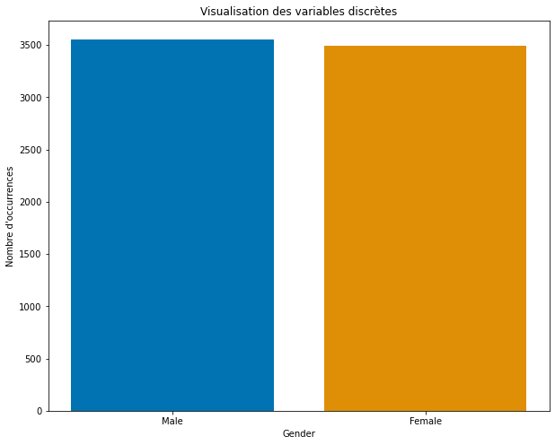

```python
# Créer une nouvelle figure avec une taille de 10x8 pouces
plt.figure(figsize=(10, 8))

# Compter le nombre d'occurrences de chaque valeur unique dans la variable discrète
counts = churn_c['Gender'].value_counts()

# Obtenir la palette de couleurs pour les valeurs uniques de la variable discrète
colors = sns.color_palette('colorblind', len(counts))

# Créer un graphique à barres verticales multicouleurs pour les valeurs uniques de la variable discrète
plt.bar(counts.index, counts.values, color=colors)

# Ajouter une légende et des étiquettes d'axe
plt.xlabel("Gender")
plt.ylabel("Nombre d'occurrences")
plt.title("Visualisation des variables discrètes")

# Afficher le graphique
plt.show()
```

```python
print(churn_c.columns)
```

```
Index(['City', 'Zip Code', 'Gender', 'Senior Citizen', 'Partner', 'Dependents',
       'Tenure Months', 'Phone Service', 'Multiple Lines', 'Internet Service',
       'Online Security', 'Online Backup', 'Device Protection', 'Tech Support',
       'Streaming TV', 'Streaming Movies', 'Contract', 'Paperless Billing',
       'Payment Method', 'Monthly Charges', 'Total Charges', 'Churn',
       'Churn Value', 'Churn Score', 'CLTV'],
      dtype='object')
```

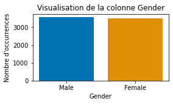

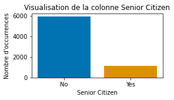

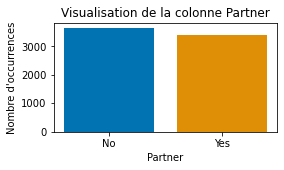

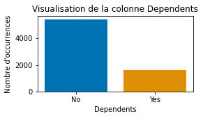

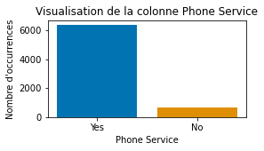

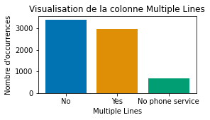

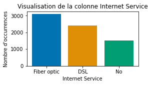

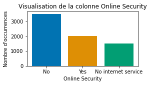

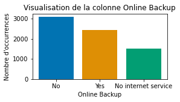

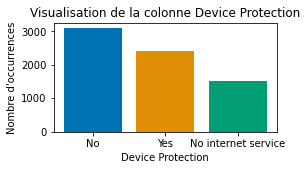

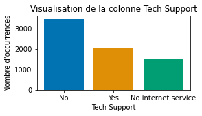

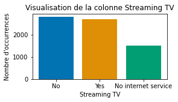

[5 more figures not shown]

```python
# Colonnes représentant des variables discrètes
columns = ['Gender', 'Senior Citizen', 'Partner', 'Dependents', 'Phone Service', 'Multiple Lines',
           'Internet Service', 'Online Security', 'Online Backup', 'Device Protection',
           'Tech Support', 'Streaming TV', 'Streaming Movies', 'Contract', 'Paperless Billing',
           'Payment Method', 'Churn']

# Parcourir les colonnes et créer un graphique à barres pour chaque colonne
for col in columns:
    # Créer une nouvelle figure avec une taille de 10x8 pouces
    plt.figure(figsize=(4, 2))

    # Compter le nombre d'occurrences de chaque valeur unique dans la colonne
    counts = churn_c[col].value_counts()

    # Obtenir la palette de couleurs pour les valeurs uniques de la colonne
    colors = sns.color_palette('colorblind', len(counts))

    # Créer un graphique à barres verticales multicouleurs pour les valeurs uniques de la colonne
    plt.bar(counts.index, counts.values, color=colors)

    # Ajouter une légende et des étiquettes d'axe
    plt.xlabel(f"{col}")
    plt.ylabel("Nombre d'occurrences")
    plt.title(f"Visualisation de la colonne {col}")

    # Afficher le graphique
    plt.show()
```

```
Processing column Gender
Processing column Senior Citizen
Processing column Partner
Processing column Dependents
Processing column Phone Service
Processing column Multiple Lines
Processing column Internet Service
Processing column Online Security
Processing column Online Backup
Processing column Device Protection
Processing column Tech Support
Processing column Streaming TV
Processing column Streaming Movies
Processing column Contract
Processing column Paperless Billing
Processing column Payment Method
Processing column Churn
```

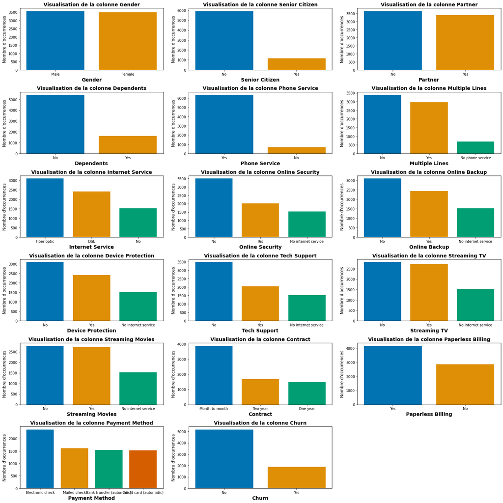

```python
# Colonnes représentant des variables discrètes
columns = ['Gender', 'Senior Citizen', 'Partner', 'Dependents', 'Phone Service', 'Multiple Lines',
           'Internet Service', 'Online Security', 'Online Backup', 'Device Protection',
           'Tech Support', 'Streaming TV', 'Streaming Movies', 'Contract', 'Paperless Billing',
           'Payment Method', 'Churn']

# Définir le nombre de graphiques par ligne
graphs_per_row = 3

# Calculer le nombre total de lignes et de colonnes nécessaires
num_rows = len(columns) // graphs_per_row
if len(columns) % graphs_per_row != 0:
    num_rows += 1
num_cols = min(len(columns), graphs_per_row)

# Créer une nouvelle figure avec une taille de 20x10 pouces
plt.figure(figsize=(20, 20))

# Parcourir les colonnes et créer un graphique à barres pour chaque colonne
for i, col_name in enumerate(columns):
    # Calculer la position du graphique dans la grille
    print(f"Processing column {col_name}") # Add print statement here
    row = i // graphs_per_row
    col = i % graphs_per_row

    # Créer un subplot pour le graphique
    plt.subplot(num_rows, num_cols, i+1)

    # Compter le nombre d'occurrences de chaque valeur unique dans la colonne
    counts = churn_c[col_name].value_counts()

    # Obtenir la palette de couleurs pour les valeurs uniques de la colonne
    colors = sns.color_palette('colorblind', len(counts))

    # Créer un graphique à barres verticales multicouleurs pour les valeurs uniques de la colonne
    plt.bar(counts.index, counts.values, color=colors)

    # Ajouter une légende et des étiquettes d'axe
    plt.xlabel(f"{col_name}", fontsize=14, fontweight='bold')
    plt.ylabel("Nombre d'occurrences", fontsize=12)
    plt.title(f"Visualisation de la colonne {col_name}", fontsize=14, fontweight='bold')

# Ajuster les espacements entre les subplots
plt.tight_layout()

# Afficher le graphique
plt.show()
```

# Observation :

##### Certaines fonctionnalités sont considérablement déséquilibrées, par exemple : 'Dependents', 'PhoneService', 'MultipleLines', 'Contract' et 'Churn'. Surtout Churn semble être critique, puisque c'est le label qui est censé être prédit.

##### on va procéder au renommage de valeur pour calculer la contribution des variables discrètes à 'Churn'

```python
columns = ['Gender', 'Senior Citizen', 'Partner', 'Dependents', 'Phone Service', 'Multiple Lines',
           'Internet Service', 'Online Security', 'Online Backup', 'Device Protection',
           'Tech Support', 'Streaming TV', 'Streaming Movies', 'Contract', 'Paperless Billing',
           'Payment Method', 'Churn']

#all colomns: No=0 , Yes=1, No internet service=2
for col in columns:
    churn_c[col].replace(['No', 'Yes'], [0, 1], inplace=True)
    churn_c[col].replace(['No internet service'], [2], inplace=True)
#Gender: Male=0 , Female=1
churn_c['Gender'].replace(['Male', 'Female'], [0, 1], inplace=True)
#Multiple Lines : No phone service=2
churn_c['Multiple Lines'].replace(['No phone service'], [2], inplace=True)
#Internet Service : DSL=1 , Fiber optic=2
churn_c['Internet Service'].replace(['DSL','Fiber optic'], [1, 2], inplace=True)
#Contract : Month-to-month=0 , One year=1 , Two year=2
churn_c['Contract'].replace(['Month-to-month','One year','Two year'], [0, 1, 2], inplace=True)
#Payment Method : Electronic check=0 , Mailed check=1 , Bank transfer(automatic)=2 , Credit card(automatic)=3
churn_c['Payment Method'].replace(['Electronic check' ,'Mailed check' ,'Bank transfer (automatic)' , 'Credit card (automatic)'], [0, 1, 2, 3], inplace=True)
```

```python
# Parcourir toutes les colonnes du dataframe
for col in churn_c.columns:

    # Calculer le nombre de valeurs distinctes dans la colonne
    n_distinct_values = churn_c[col].nunique()

    # Afficher le nombre de récurrences de chaque valeur dans la colonne
    value_counts = churn_c[col].value_counts()

    # Afficher les résultats
    print("Colonne : ", col)
    print("Nombre de valeurs distinctes : ", n_distinct_values)
    print("Nombre de récurrence de chaque valeur : \n", value_counts)
    print("\n")
```

```
Colonne :  City
Nombre de valeurs distinctes :  1129
Nombre de récurrence de chaque valeur :
 Los Angeles       305
San Diego         150
San Jose          112
Sacramento        108
San Francisco     104
                 ...
Healdsburg          4
Jenner              4
Philo               4
Point Arena         4
Olympic Valley      4
Name: City, Length: 1129, dtype: int64


Colonne :  Zip Code
Nombre de valeurs distinctes :  1652
Nombre de récurrence de chaque valeur :
 90003    5
91436    5
91916    5
91913    5
91911    5
        ..
95303    4
95251    4
95250    4
95246    4
96146    4
Name: Zip Code, Length: 1652, dtype: int64


Colonne :  Gender
Nombre de valeurs distinctes :  2
Nombre de récurrence de chaque valeur :
 0    3555
1    3488
Name: Gender, dtype: int64
```

[output cut: 217 more lines]

```
Colonne :  CLTV
Nombre de valeurs distinctes :  3438
Nombre de récurrence de chaque valeur :
 5546    8
4741    7
5527    7
5092    7
4745    7
       ..
2364    1
3003    1
5280    1
3269    1
5553    1
Name: CLTV, Length: 3438, dtype: int64
```

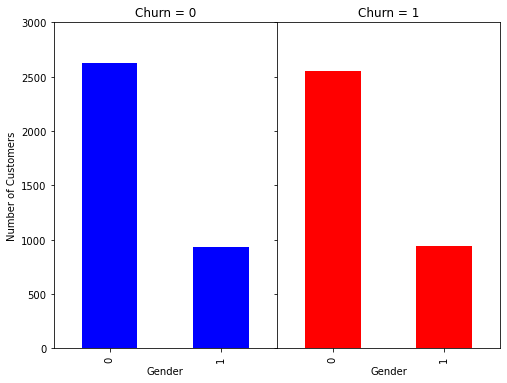

```python
# Créer une nouvelle figure avec une taille de 8x6 pouces
plt.figure(figsize=(8, 6))

# Créer contingency table de Gender et Churn
contingency_table = pd.crosstab(churn_c['Gender'], churn_c['Churn'])

# Visualiser la contribution de Gender à Churn, pour Churn = 0 et Churn = 1
churn_0 = contingency_table.loc[0, :]
churn_1 = contingency_table.loc[1, :]

plt.subplot(1, 2, 1)
churn_0.plot(kind='bar', color='blue')
plt.title('Churn = 0')
plt.xlabel('Gender')
plt.ylabel('Number of Customers')
plt.ylim([0, 3000])

plt.subplot(1, 2, 2)
churn_1.plot(kind='bar', color='red')
plt.title('Churn = 1')
plt.xlabel('Gender')
plt.ylim([0, 3000])
plt.gca().axes.yaxis.set_ticklabels([]) # disable y-axis tick labels

plt.subplots_adjust(wspace=0)
plt.show()
```

###### 'Gender' ne semble pas être une caractéristique précieuse pour la prévision du taux de désabonnement. Les valeurs sont uniformément réparties

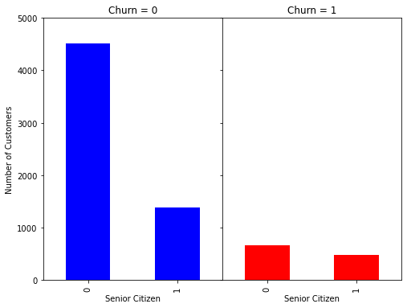

```python
# Créer une nouvelle figure avec une taille de 8x6 pouces
plt.figure(figsize=(8, 6))

# Créer contingency table de Senior Citizen et Churn
contingency_table = pd.crosstab(churn_c['Senior Citizen'], churn_c['Churn'])

# Visualiser la contribution de Senior Citizen à Churn, pour Churn = 0 et Churn = 1
churn_0 = contingency_table.loc[0, :]
churn_1 = contingency_table.loc[1, :]

plt.subplot(1, 2, 1)
churn_0.plot(kind='bar', color='blue')
plt.title('Churn = 0')
plt.xlabel('Senior Citizen')
plt.ylabel('Number of Customers')
plt.ylim([0, 5000])

plt.subplot(1, 2, 2)
churn_1.plot(kind='bar', color='red')
plt.title('Churn = 1')
plt.xlabel('Senior Citizen')
plt.ylim([0, 5000])
plt.gca().axes.yaxis.set_ticklabels([]) # disable y-axis tick labels

plt.subplots_adjust(wspace=0)
plt.show()
```

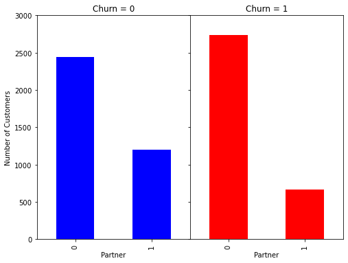

```python
# Créer une nouvelle figure avec une taille de 8x6 pouces
plt.figure(figsize=(8, 6))

# Créer contingency table de Partner et Churn
contingency_table = pd.crosstab(churn_c['Partner'], churn_c['Churn'])

# Visualiser la contribution de Partner à Churn, pour Churn = 0 et Churn = 1
churn_0 = contingency_table.loc[0, :]
churn_1 = contingency_table.loc[1, :]

plt.subplot(1, 2, 1)
churn_0.plot(kind='bar', color='blue')
plt.title('Churn = 0')
plt.xlabel('Partner')
plt.ylabel('Number of Customers')
plt.ylim([0, 3000])

plt.subplot(1, 2, 2)
churn_1.plot(kind='bar', color='red')
plt.title('Churn = 1')
plt.xlabel('Partner')
plt.ylim([0, 3000])
plt.gca().axes.yaxis.set_ticklabels([]) # disable y-axis tick labels

plt.subplots_adjust(wspace=0)
plt.show()
```

##### Les clients sans partenaire sont un peu plus susceptibles de chuter

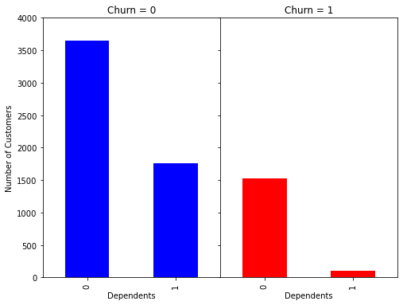

```python
# Créer une nouvelle figure avec une taille de 8x6 pouces
plt.figure(figsize=(8, 6))

# Créer contingency table de Dependents et Churn
contingency_table = pd.crosstab(churn_c['Dependents'], churn_c['Churn'])

# Visualiser la contribution de Dependents à Churn, pour Churn = 0 et Churn = 1
churn_0 = contingency_table.loc[0, :]
churn_1 = contingency_table.loc[1, :]

plt.subplot(1, 2, 1)
churn_0.plot(kind='bar', color='blue')
plt.title('Churn = 0')
plt.xlabel('Dependents')
plt.ylabel('Number of Customers')
plt.ylim([0, 4000])

plt.subplot(1, 2, 2)
churn_1.plot(kind='bar', color='red')
plt.title('Churn = 1')
plt.xlabel('Dependents')
plt.ylim([0, 4000])
plt.gca().axes.yaxis.set_ticklabels([]) # disable y-axis tick labels

plt.subplots_adjust(wspace=0)
plt.show()
```

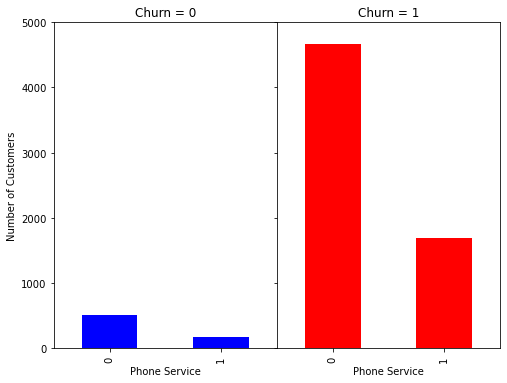

```python
# Créer une nouvelle figure avec une taille de 8x6 pouces
plt.figure(figsize=(8, 6))

# Créer contingency table de Phone Service et Churn
contingency_table = pd.crosstab(churn_c['Phone Service'], churn_c['Churn'])

# Visualiser la contribution de Phone Service à Churn, pour Churn = 0 et Churn = 1
churn_0 = contingency_table.loc[0, :]
churn_1 = contingency_table.loc[1, :]

plt.subplot(1, 2, 1)
churn_0.plot(kind='bar', color='blue')
plt.title('Churn = 0')
plt.xlabel('Phone Service')
plt.ylabel('Number of Customers')
plt.ylim([0, 5000])

plt.subplot(1, 2, 2)
churn_1.plot(kind='bar', color='red')
plt.title('Churn = 1')
plt.xlabel('Phone Service')
plt.ylim([0, 5000])
plt.gca().axes.yaxis.set_ticklabels([]) # disable y-axis tick labels

plt.subplots_adjust(wspace=0)
plt.show()
```

##### Le service téléphonique semble avoir peu d'impact sur la décision du client

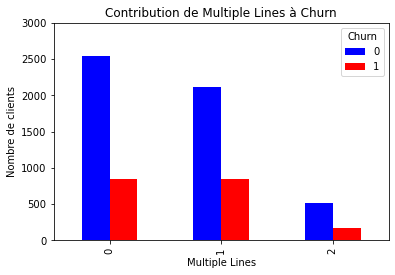

```python
# Créer une nouvelle figure avec une taille de 8x6 pouces
plt.figure(figsize=(8, 6))

# Create a contingency table of MultipleLines and Churn
contingency_table = pd.crosstab(churn_c['Multiple Lines'], churn_c['Churn'])

# Afficher le tableau en un graphique en barres
contingency_table.plot.bar(color=['blue', 'red'])
plt.title('Contribution de Multiple Lines à Churn')
plt.xlabel('Multiple Lines')
plt.ylabel('Nombre de clients')
plt.ylim([0, 3000])

plt.show()
```

###### 'Multiple lines' semble aussi avoir peu d'impact sur la décision du client

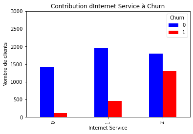

```python
# Créer une nouvelle figure avec une taille de 8x6 pouces
plt.figure(figsize=(8, 6))

# Create a contingency table of MultipleLines and Churn
contingency_table = pd.crosstab(churn_c['Internet Service'], churn_c['Churn'])

# Afficher le tableau en un graphique en barres
contingency_table.plot.bar(color=['blue', 'red'])
plt.title('Contribution dInternet Service à Churn')
plt.xlabel('Internet Service')
plt.ylabel('Nombre de clients')
plt.ylim([0, 3000])

plt.show()
```